# Map Visualizations

## Visualization through maps in R

##### Data Viz for Public Policy

##### October 29th, 2017

This is Assignment 5 of the class “Data Visualization in Public Policy” at UChicago (Fall, 2017) and involves producing meaningful maps and narratives to accompany them.

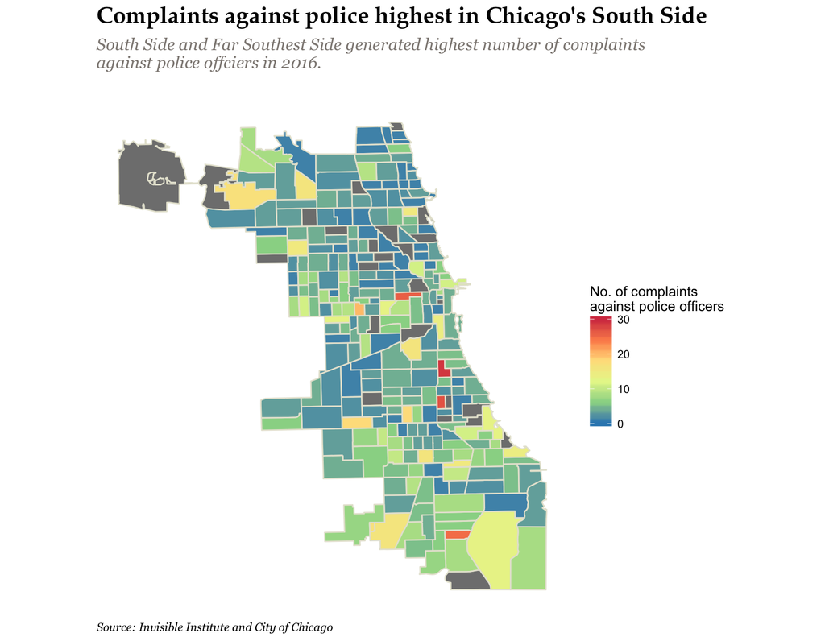

Highest number of complaints tend to generate against police officers who are in beats in South Side and Far Southeast Side Chicago. The number of complaints against police officers decrease as one travels from the South to the North of Chicago.

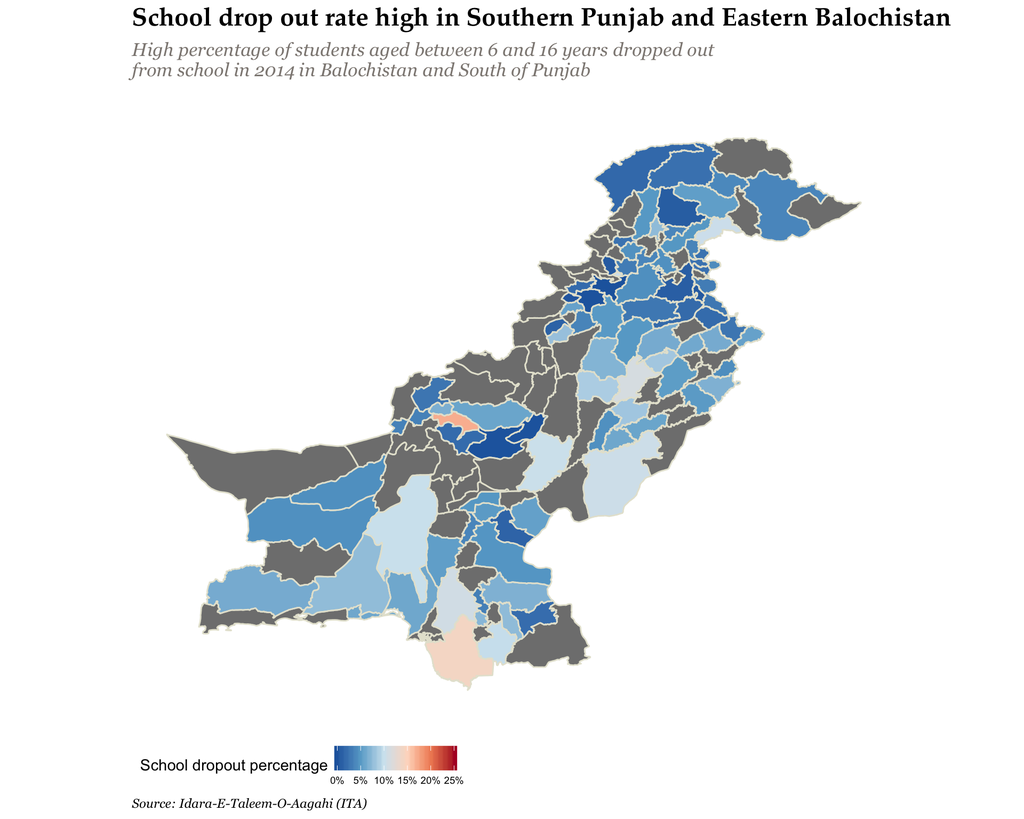

While the 2014 data on drop out rate of students aged between 6 and 16 years for some districts is not available, it can be seen that the highest school drop out rate is registered in Southern Punjab and Mid- and Southern Balochistan. The school drop out rate in the North of Pakistan is relatively better than the average.

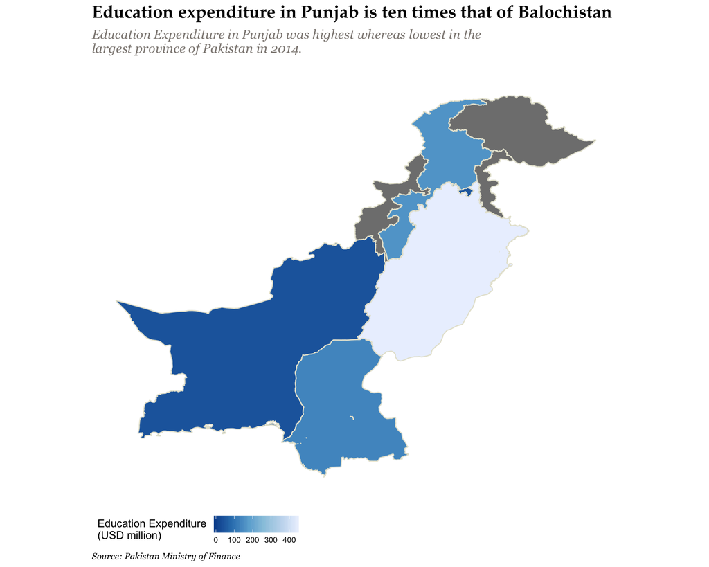

The previous figure showed that drop out rate is highest in Southern Punjab and Southern Balochistan. This picture shows that the education expenditure in 2014 was highest in the province of Punjab, the most industrial and economically active province of Pakistan. It is possible that most education expenditure in Punjab was allocated to the northern or middle areas of the province.

Balochistan, the largest province of Pakistan, reported the lowest amount of education expenditure – almost the same amount as that of Islamabad, the capital city of Pakistan. This explains the reason why many parts of Balochistan had above average school drop out rate.